# Medical Appointment No Shows Data Analysis Project

### 1- The dataset that analyzed in this analysis:</b>

> -In this project we'll be analyzing data associated with medical appointments that focused on the question of whether or not patients show up for their appointment, and what are the factors that affects no-show ups for the appointment.
> - The dataset is from :https://www.kaggle.com/joniarroba/noshowappointments

> **Dataset Properties:**

> > **110527 rows** , and **14 variables**

> > **Variables meaning:**

> > **1 - PatientId:** Identification of a patient.

> > **2 - AppointmentID:** Identification of each appointment.

> > **3 - Gender:** Male or Female.

> > **4 - DataMarcacaoConsulta:** The day of the actuall appointment, when they have to visit the doctor.

> > **5 - DataAgendamento:** The day someone called or registered the appointment, this is before appointment.

> > **6 - Age:** How old is the patient.

> > **7 - Neighbourhood:** Where the appointment takes place.

> > **8 - Scholarship:** True of False . (scholarship for poor people in Brazil).

> > **9 - Hipertension:** True or False.

> > **10 - Diabetes:** True or False.

> > **11 - Alcoholism:** True or False.

> > **12 - Handcap:** True or False.

> > **13 - SMS_received:** 1 or more messages sent to the patient.

> > **14 - No-show:** True or False.

> -**One dependent variable**

> > -No_show

> -**13 independent variables**

> > the rest of the variables are independed

> -**As we have a dataset first so we are going to ask questions based on it**.

### 2-The posed question(s):

> **Questions we are going to answer at the end:**

> > 1-What factors are important for us to know in order to predict if a patient will show up for their scheduled appointment?

> > 2- does the neighborhood is an important factor that make the patient doesnot show up?

> > 3-The waiting time of the patient between the schedule day and the appointment day influences it's no showing?

> **Questions to think about?** >

> > 5-does the patients with scholarships show up more than those who are not?

> > 6- does the gender affects the showing up to the appointment?

### 3- A description of what you did to investigate those questions:

> -i have tried to look at first on the dataset and get what is want to be cleaned

> -and what is the features that may affect the independent variable.

> -and is there any extra questions poped up in my head to return back and add them.

> after data wrangling, i took the variables that may may answer my questions and start to investigate each variable at first alone , and look at any indications that might answer my questions before i took that variable and mix it up with another variable to make sure of my suspetions.(i come with an answers for my questions from this step) i also used for sure graphs and plots to make the visualization more powerful and be easy for any one will look into this analysis.

> then i tried to look again if there is any other variables i discard at first may influence in answering my questions after i understands the data much more.

> at the end i tried to sum up what i concluded from this analysis and try to make an easy explanation for the questions i posed at first, with no getting to much into the details.

### 4- Data wrangling steps:

> Here we are going to do 2 steps: >

> > 1- **Assessing Data:** exploring data and giving comments over all the weired, wrong, and missing values in the data.

> > 2- **Cleaning data:** clean the data by using the comments we wrote.

> > there is a third step should be at the first which is Gathering the Data but we already have the Dataset Gathered.

##### 1- Assessing Data: exploring data and giving comments over all the weired, wrong, and missing values in the data. without making any change in the data.

> -We can drop the indepentent variable like **AppointmentID** as it is not affecting the dependent variable **No-show** in predicting whether or not the patient is going to show up.

> -**AppointmentDay** has **00:00:00** in its **TimeStamp** we will **remove** it.

> -in **ScheduledDay**, as we are going to remove the time from the **AppointmentDay** column we will do that here too. the time in schedule day is not important as if the time were assigned in appointment day.

> -There is misspelling in columns names like : **Hipertension**, the correct name should be **Hypertension**.

> -There is misspelling in columns names like : **Handcap**, the correct name should be **Handicap**.

> -Changing column **SMS_received** name to **SMSReceived** whould be better.

> -Changing column **No-show** name to **NoShow** whould be better.

> -An important thing about **No-show** column values, that **Yes** means that the patient didn't show at the appointment.

> -Calculating the **WaitingTime** between the **ScheduledDay** and **AppointmentDay**, and setting the result in a new column with **WaitingTime** name. it could be useful.

> -We can see that **Age** minimium value is **-1** and the maximum value is **115** ! that range indicates that there is an **outlaiers** in that column.

> -Also from here we can check for the **missing values** from count row. and the count row showes that there is **no missing values**.

> -We can see that there is **no missing values** in this dataset.

> -**PatientId** is a **float64 datatype**, it is better to parsing it to **int64 datatype**.

> -**AppointmentDay** is an **object datatype**, it is better to parsing it to **DateTime datatype**.

> -**ScheduledDay** is an **object datatype**, it is better to parsing it to **DateTime datatype**.

> -**No-show** coulmn have to be changed from **yes-no** to **1-0** in a new column for better further use, with **int64 datatype**.

> -No **duplicated rows** in the dataset.

> -the number of the unique values in **ScheduledDay** is more than the number of the unique values in **AppointmentDay**, as the time is not assigned in the **AppointmentDay**.

#### 2- Cleaning Data:

Data that we are going to clean :

> -Dropping the indepentent variables **PatientId** and **AppointmentID**.

> -Removing time from **AppointmentDay**.

> -Removing time from **ScheduledDay**.

> -Correcting column **Hipertension** name to **Hypertension**.

> -Correcting column **Handcap** name to **Handicap**.

> -Changing column **SMS_received** name to **SMSReceived**.

> -Changing column **No-show** name to **NoShow**.

> -**PatientId** is a **float64 datatype**, it is better to parsing it to **int64 datatype**.

> -Parsing **AppointmentDay** **object datatype** to **DateTime datatype**.

> -Parsing **ScheduledDay** **object datatype** to **DateTime datatype**.

> -**No-show** coulmn have to be encoded from **yes-no** to **1-0** for better further use.

> -Calculate WaitingTime between the **AppointmentDay** and the **ScheduledDay** and save the results in a new column with name **WaitingTime**.to see whether or not the **WaitingTime** affects if the patient show up or not for the appointment.

> -Adding new column for making the values of the **WaitingTime** column be categorical, and save the results in a column with name **WaitingTimeGroup**.

> -That -1 one record in **Age column**, is more likely a mistake while entering data, and it will not affect any thing id we remove that row.

> -Checks for No wrong assigned **ScheduledDay** aheads **AppointmentDay** Dates.

### 5- Summary statistics and plots communicating your final results

##### 5.1-Age

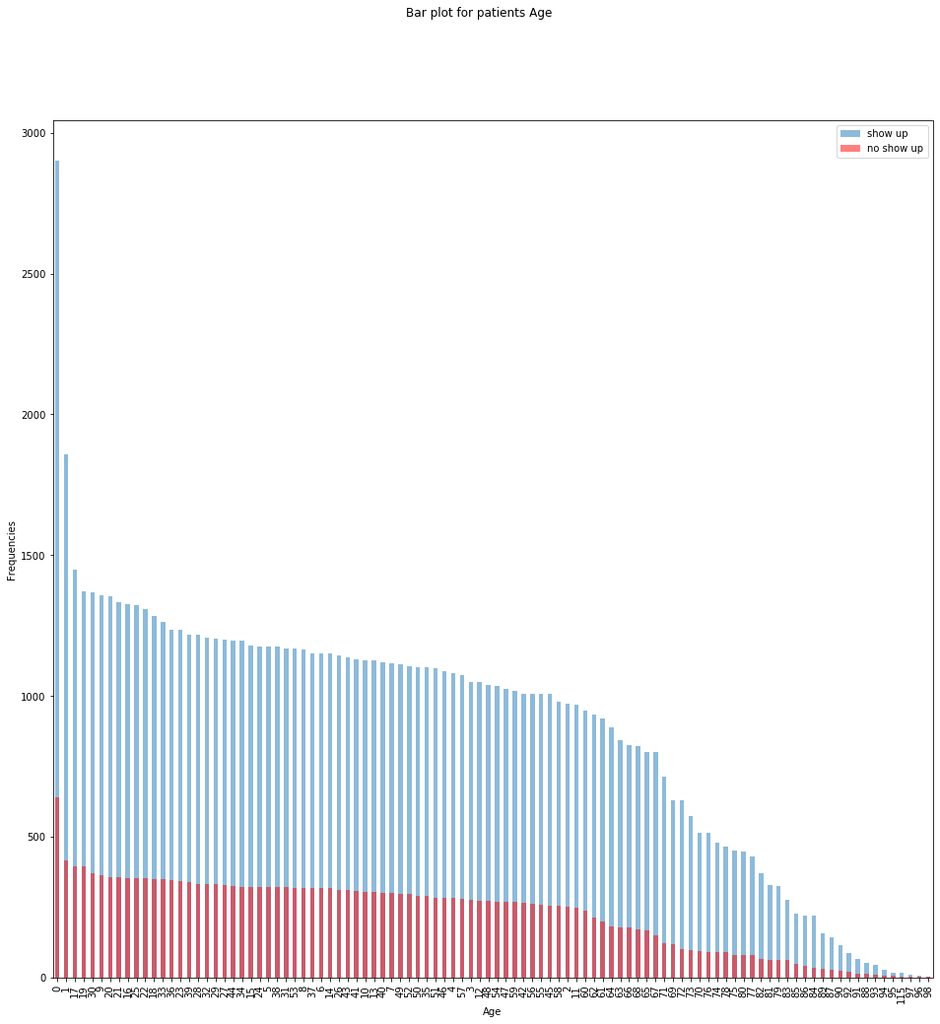

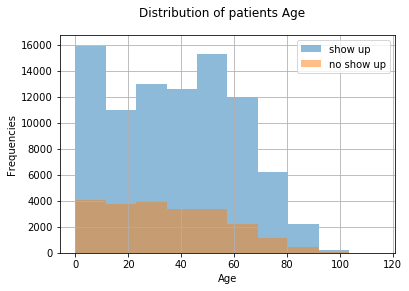

> **Comments:**

> -it seems that as much the ages get higher is not an indication for not showing up. but it might give a good relevance if it mixed with another variable.

> -a small portion of patients that did not showup are above 70

> -the distribution is right skewed a little bit.

###### 5.2-Patient ID

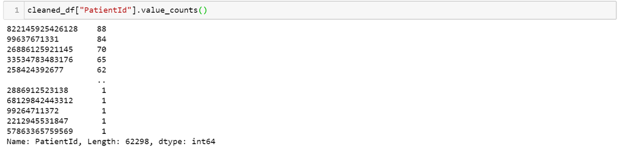

> **Comments:**

> we found that there are patients have regiestered for more than one appointment , that means they are frequently come to that hospital for different appointments, or they may have rescudle their appointment.

###### 5.3-SMSReceived

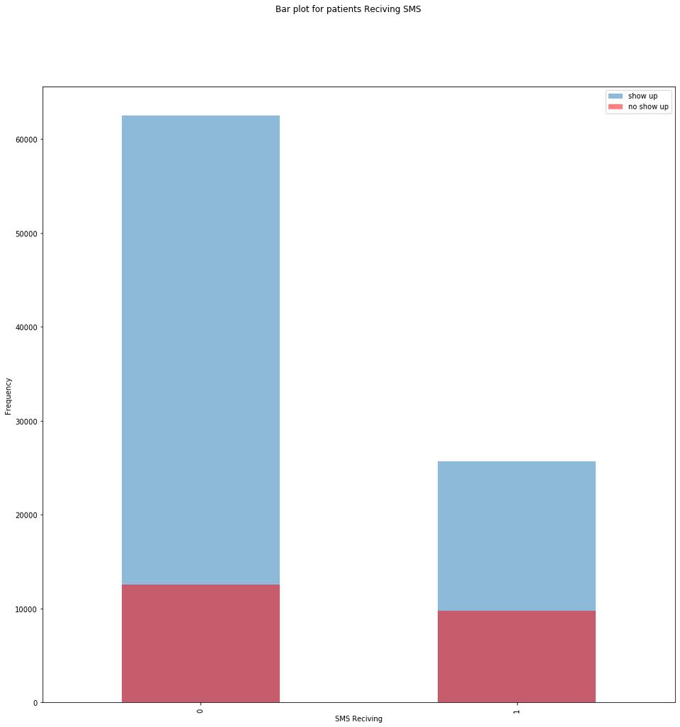

> **Comments:**

##### 5.4-Neighbourhood

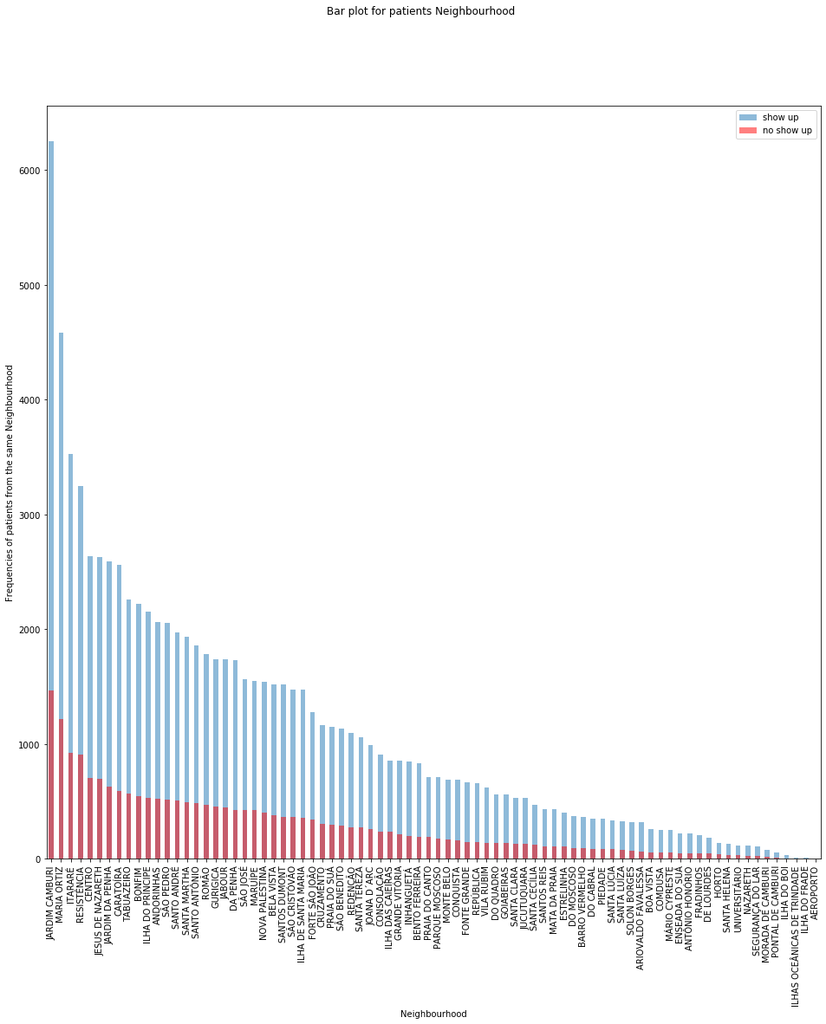

> **Comments:**

##### 5.5-WaitingTime

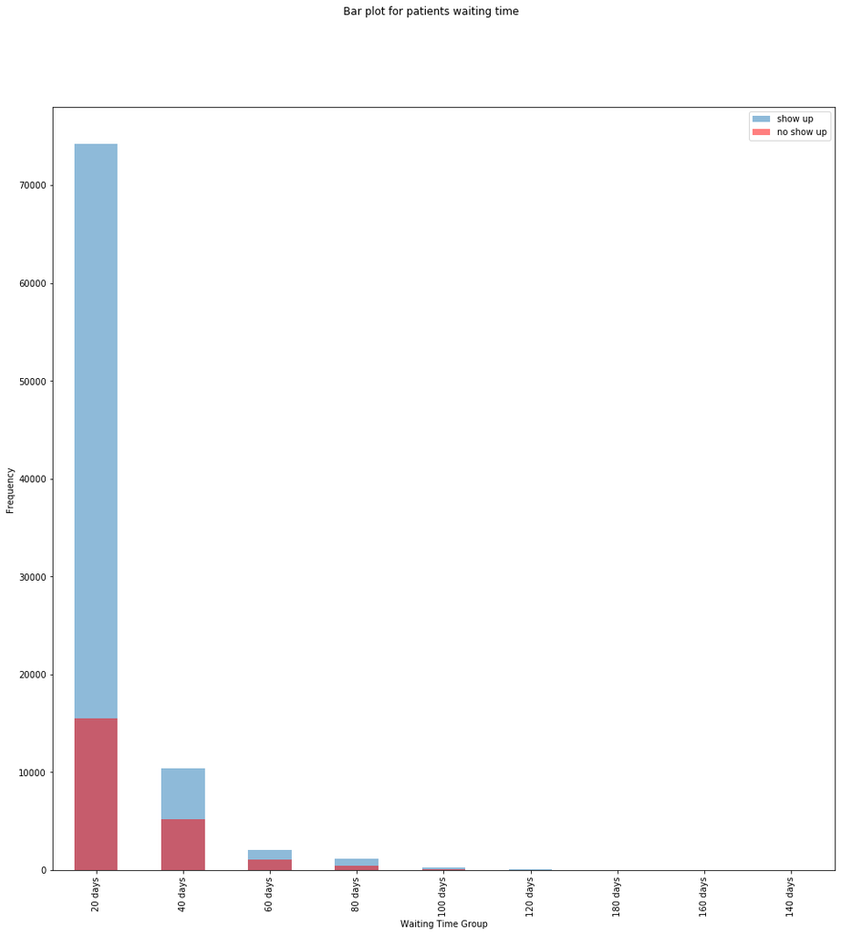

> **Comments:**

> that gives a strong indication that as long the waiting time increases the showing up for the appoientments decreases.

###### 5.6-NoShow

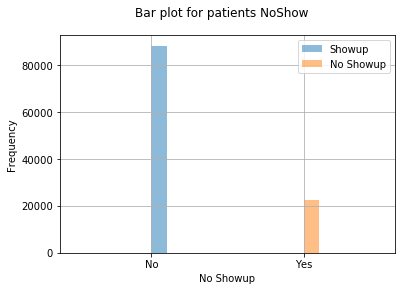

> **Comments:**

> it seems that people that show up more than the people that does not show up.

> this dataset is not balanced.

### 6-Answering Questions

#### Questions:

> > 1-What factors are important for us to know in order to predict if a patient will show up for their scheduled appointment?

> > 3-The waiting time of the patient between the schedule day and the appointment day influences it's no showing?

#### 1-What factors are important for us to know in order to predict if a patient will show up for their scheduled appointment?

> -Alot of the insights here that have relevance that may influences no showup for their appointment if we mixed these variables up.

> -Variables that have relevance that may influences that patient not showing up:

> > -Age

> > -Waiting days

> > -Neighbourhood

> > -PatientsID: get patients who registered more than one time (reschedule).

#### 3- The waiting time of the patient between the schedule day and the appointment day influences it's no showing?

> Yes!, we found that the most of patients that showed up for their appointments their waiting time between the scheduled day and appointment day is between 0-20 days with a ratio more than the patients that showed up for their appointments and their waiting time between 20-40 days and 40-60 days. that gives an indication that as log the waiting time increases the chance that the patient doesn't show up increases.

## 7-Conclusions

this analysis is performed on medical appointment no shows,

the purpose of this analysis is to go deeper why patients dont show up for their appointment. And what are the main factors that affects the no show up chances.

their are few issues with the dataset like negative values or outlaiers.

-most of the variables are categorical or binary valued , that meaks us can't analysis more variables distribution and the relationships between each other and if we be able to create a predictive model by logistic regression or any other classifiers.

> Age >

> > and we thought that the baby/child patients that didn't show up, their parents might faced some difficulities in bringing the baby or child. to the appointment. and that might makes the rate of not showing up increases.

> PatientId

> > there many patients have reschedule their appointments, they may have missed their appointments and attend in the rescudule appointment.

> SMSRecived

> Neighbourhood

> Waiting time

> > by increasing the waiting time, the showing up chances for the appointment decreases.

> NoShow

> > the patients that show up more than the patients that does not show up.

> So we can say that **Age** and **Neighbourhood** and **WaitingTime** are the most important factors that affects the chances the patient shows up or not .

## 8-Limitations

> -some variables like neighbourhood would be very useful if we have the addresses of the patients and go deeper whether or not the distance is really an issue for the people who didn't show up. it is an important variable but doesnot have many information to go deeper behind

> -WaitingTime new variable, its datatype is timedelta, and applying bins to that variable to plot it causes many errors , so i tried to make WaitingTimeGroups manually step by step.it would be better if using bins works.

## 9-References:

https://www.kaggle.com/joniarroba/noshowappointments

https://www.kaggle.com/joniarroba/noshowappointments/discussion/29699#229356

https://www.python-course.eu/pandas_python_binning.php

https://www.pylenin.com/blogs/mastering-python-datetime/

https://matplotlib.org/3.1.1/gallery/subplots_axes_and_figures/figure_title.html

https://stackoverflow.com/questions/12444716/how-do-i-set-the-figure-title-and-axes-labels-font-size-in-matplotlib

https://stackoverflow.com/questions/4628122/how-to-construct-a-timedelta-object-from-a-simple-string

https://stackoverflow.com/questions/53699809/binning-pandas-column-of-timestamps

https://stackoverflow.com/questions/43500894/pandas-pd-cut-binning-datetime-column-series

https://dfrieds.com/data-analysis/bin-values-python-pandas.html